# scATAC-seq Rat Metrial Glands

Ha T. H. Vu

This is a documentation for analyses of scATAC-seq data, generated from rat metrial gland tissues on gestational day (GD) 15.5 and 19.5.

```r
library("org.Rn.eg.db")
library("clusterProfiler")

go <- function(genes) {
  GO <- enrichGO(gene = genes, OrgDb=org.Rn.eg.db, ont = "BP", pvalueCutoff = 0.05, qvalueCutoff = 0.05, maxGSSize=500, readable = T, keyType = "ENSEMBL")
  goSimplify <- simplify(GO)
  res <- as.data.frame(goSimplify)
  #res$Rank <- seq(1, nrow(res))
  res$GeneRatio <- sapply(strsplit(res$GeneRatio, "/"), function(x) as.numeric(x[1])/as.numeric(x[2]))
  res$BgRatio <- sapply(strsplit(res$BgRatio, "/"), function(x) as.numeric(x[1])/as.numeric(x[2]))
  res$Fold <- as.numeric(res$GeneRatio)/as.numeric(res$BgRatio)
  res <- res[res$qvalue <= 0.05 & res$Fold >= 2 & res$Count >= 5,]

  return(res)
}
```

# gd 15.5 ver 2

```r
library(Signac)
library(Seurat)
library(ggplot2)
library(ggpubr)
library(GenomicRanges)
library(patchwork)
library(BSgenome.Rnorvegicus.Ensembl.rn6)
set.seed(1234)

load("/work/LAS/geetu-lab/hhvu/project3_scATAC/rnor6.rda")
load("/work/LAS/geetu-lab/hhvu/project3_scATAC/rnor6.ranges.rda")
load("/work/LAS/geetu-lab/hhvu/project3_scATAC/scATAC-seq-analysis/4_RNAintegration/scRNA-seqFiles/gd15.5_res0.8.rda")

exp <- AverageExpression(data)
exp <- as.data.frame(exp$RNA)

load("/work/LAS/geetu-lab/hhvu/project3_scATAC/scATAC-seq-analysis/4_RNAintegration/2_MACS2Peaks/annotation_scRNAseq/gd15.5-ATACwithRNAlables.rda")
Idents(rats) <- rats@meta.data$predicted.id # change from old identities to those predicted by scRNA-seq
DefaultAssay(rats) <- 'MACSpeaks'
Annotation(rats) <- rnor6.ranges
```

What if I use all TBC (specific or not) peaks together, genes are markers or not:

```r
c <- rownames(rats@meta.data[rats@meta.data$predicted.id == "Invasive trophoblast cells",])
atac2 <- rats@assays$MACSpeaks[,c]
atac3 <- atac2[rowMeans(atac2) > 0,]
atac3 <- atac2[rowSums(atac2 > 0) >= ncol(atac2)/10, ]
dim(atac3)
```

```
#> [1] 22602   128
```

```r
closest_genes <- ClosestFeature(rats, regions = rownames(atac3))

t <- table(closest_genes$gene_name)

genes <- names(t[t >= 3])

exp <- exp[order(rownames(exp)),]
exp$gene <- rownames(exp)
df <- exp[exp$gene %in% names(t), c("gene", "23")]
colnames(df) <- c("gene", "value")
df2 <- data.frame(gene = setdiff(names(t), df$gene), value = rep(0, length(setdiff(names(t), df$gene))))
names(df2) <- colnames(df)
df <- rbind(df, df2)

df$category <- ifelse(df$gene %in% genes, ">= 3 peaks", "< 3 peaks")

wilcox.test(df[df$category == ">= 3 peaks", "value"], df[df$category == "< 3 peaks", "value"])
```

```
#>
#>  Wilcoxon rank sum test with continuity correction
#>
#> data:  df[df$category == ">= 3 peaks", "value"] and df[df$category == "< 3 peaks", "value"]
#> W = 12828076, p-value < 2.2e-16
#> alternative hypothesis: true location shift is not equal to 0
```

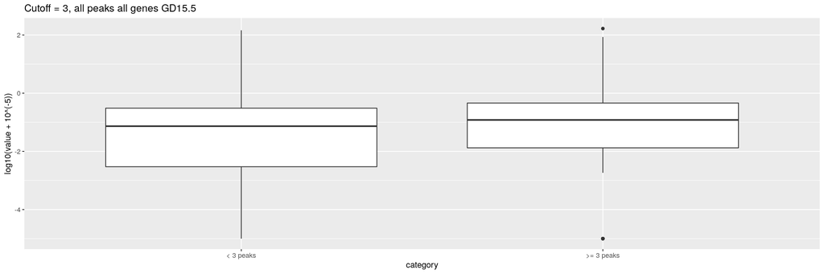

```r
ggplot(df, aes(x=category, y=log10(value+10^(-5)))) + geom_boxplot() + ggtitle("Cutoff = 3, all peaks all genes GD15.5")
```

```r
print("Number of genes with >= 3 peaks:")
```

```
#> [1] "Number of genes with >= 3 peaks:"
```

```r
length(genes)
```

```
#> [1] 2462
```

```r
print("Number of genes with < 3 peaks:")
```

```
#> [1] "Number of genes with < 3 peaks:"
```

```r
length(unique(df[df$category == "< 3 peaks", "gene"]))
```

```
#> [1] 9359
```

Within markers, the same is not observed (genes with >= 3 peaks or < 3 peaks are equally expressed). I think it’s because markers are highly expressed already.

```r
c <- rownames(rats@meta.data[rats@meta.data$predicted.id == "Invasive trophoblast cells",])
atac2 <- rats@assays$MACSpeaks[,c]
atac3 <- atac2[rowMeans(atac2) > 0,]
atac3 <- atac2[rowSums(atac2 > 0) >= ncol(atac2)/10, ]
dim(atac3)
```

```
#> [1] 22602   128
```

```r
closest_genes <- ClosestFeature(rats, regions = rownames(atac3))

t <- table(closest_genes$gene_name)

genes <- names(t[t >= 3])

exp <- exp[order(rownames(exp)),]
exp$gene <- rownames(exp)
df <- exp[exp$gene %in% names(t), c("gene", "23")]
colnames(df) <- c("gene", "value")
df2 <- data.frame(gene = setdiff(names(t), df$gene), value = rep(0, length(setdiff(names(t), df$gene))))
names(df2) <- colnames(df)
df <- rbind(df, df2)

df$category <- ifelse(df$gene %in% genes, ">= 3 peaks", "< 3 peaks")

marker <- read.table("/work/LAS/geetu-lab/hhvu/project3_scATAC/scATAC-seq-analysis/4_RNAintegration/scRNA-seqFiles/gd15.5-wilcoxin-cluster23.txt", header = T)

df <- df[df$gene %in% marker$gene,]

wilcox.test(df[df$category == ">= 3 peaks", "value"], df[df$category == "< 3 peaks", "value"])
```

```
#>
#>  Wilcoxon rank sum test with continuity correction
#>
#> data:  df[df$category == ">= 3 peaks", "value"] and df[df$category == "< 3 peaks", "value"]
#> W = 14821, p-value = 0.5778
#> alternative hypothesis: true location shift is not equal to 0
```

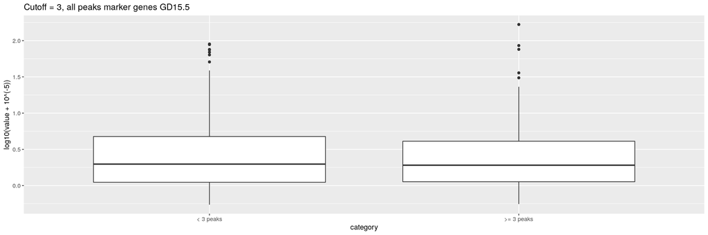

```r
ggplot(df, aes(x=category, y=log10(value+10^(-5)))) + geom_boxplot() + ggtitle("Cutoff = 3, all peaks marker genes GD15.5")
```

Peak distribution of marker genes:

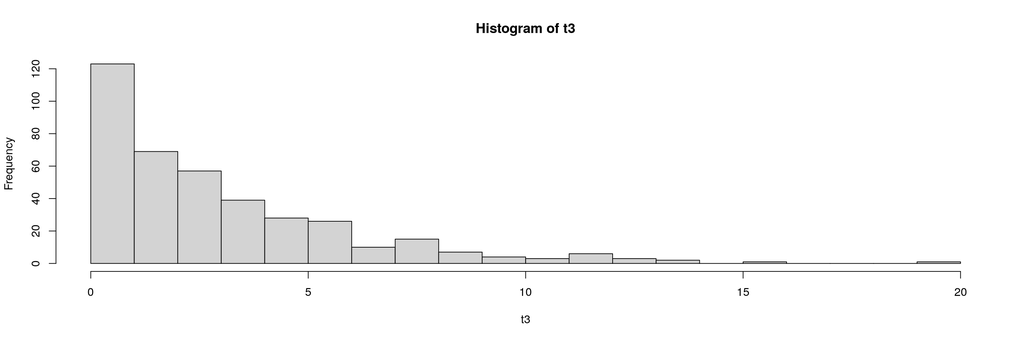

```r
marker <- read.table("/work/LAS/geetu-lab/hhvu/project3_scATAC/scATAC-seq-analysis/4_RNAintegration/scRNA-seqFiles/gd15.5-wilcoxin-cluster23.txt", header = T)
t2 <- t[intersect(names(t),marker$gene)]
non <- setdiff(marker$gene, names(t))
nont <- rep(0, length(non))
names(nont) <- non
t3 <- as.vector(t2)
names(t3) <- names(t2)
t3 <- c(t3, nont)
hist(t3, breaks = seq(0, 20, 1))
```

```r
length(t3[t3 >= 3])
```

```
#> [1] 202
```

202 out of 394 marker genes have >= 3 peaks.  
Of the markers with peaks, how many peaks are specific

```r
specificPeaks <- read.table("/work/LAS/geetu-lab/hhvu/project3_scATAC/scATAC-seq-analysis/4_RNAintegration/2_MACS2Peaks/annotation_scRNAseq/gd15.5-tbc-toGenes.txt", sep = "\t")
df2 <- closest_genes[closest_genes$gene_name %in% marker$gene,]

#number of specific peaks associated to markers
length(intersect(df2$query_region, specificPeaks$query_region))
```

```
#> [1] 423
```

```r
#number of peaks associated to markers
length(df2$query_region)
```

```
#> [1] 1345
```

```r
#number of non-specific peaks
length(setdiff(closest_genes$query_region, specificPeaks$query_region))
```

```
#> [1] 18760
```

```r
dat <- data.frame(marker=c(423,1345-423), nonmarker=c(3842-423,18760-(3842-423)))
rownames(dat) <- c("specific", "nonspecific")
dat
```

```
#>             marker nonmarker
#> specific       423      3419
#> nonspecific    922     15341
```

```r
fisher.test(dat, alternative = "greater")
```

```
#>
#>  Fisher's Exact Test for Count Data
#>
#> data:  dat
#> p-value < 2.2e-16
#> alternative hypothesis: true odds ratio is greater than 1
#> 95 percent confidence interval:
#>  1.855722      Inf
#> sample estimates:
#> odds ratio
#>   2.058507
```

Markers that only have nonspecific peaks:

```r
nonSpe <- df2[df2$query_region %in% setdiff(closest_genes$query_region, specificPeaks$query_region),]
onlyNonSpe <- nonSpe[!(nonSpe$gene_name %in% specificPeaks$gene_name),]

go_onlyNonSpe <- go(rnor6[rnor6$gene_name %in% onlyNonSpe$gene_name, 1])

go_onlyNonSpe[grep("epith|placenta|actin|vascul", go_onlyNonSpe$Description),]
```

```
#>                    ID                                            Description
#> GO:0008064 GO:0008064 regulation of actin polymerization or depolymerization
#> GO:0030832 GO:0030832                    regulation of actin filament length
#> GO:0032970 GO:0032970             regulation of actin filament-based process
#> GO:0008154 GO:0008154               actin polymerization or depolymerization
#>             GeneRatio    BgRatio       pvalue     p.adjust       qvalue
#> GO:0008064 0.07746479 0.01003306 1.930375e-07 0.0002300214 0.0002046627
#> GO:0030832 0.07746479 0.01014905 2.168322e-07 0.0002300214 0.0002046627
#> GO:0032970 0.10563380 0.02226991 6.561184e-07 0.0003764681 0.0003349643
#> GO:0008154 0.07746479 0.01177289 9.543201e-07 0.0004553697 0.0004051675
#>                                                                                               geneID
#> GO:0008064                         Vasp/Plekhg2/Pfn1/Arpc1b/Dbn1/Trim27/Cotl1/Tmsb10/Arf6/Lima1/Nck1
#> GO:0030832                         Vasp/Plekhg2/Pfn1/Arpc1b/Dbn1/Trim27/Cotl1/Tmsb10/Arf6/Lima1/Nck1
#> GO:0032970 Vasp/Plekhg2/Pfn1/Jup/Arpc1b/Ccdc88a/Dbn1/Trim27/Cotl1/Arhgdib/Sri/Tmsb10/Arf6/Lima1/Nck1
#> GO:0008154                         Vasp/Plekhg2/Pfn1/Arpc1b/Dbn1/Trim27/Cotl1/Tmsb10/Arf6/Lima1/Nck1
#>            Count     Fold
#> GO:0008064    11 7.720956
#> GO:0030832    11 7.632716
#> GO:0032970    15 4.743343
#> GO:0008154    11 6.579928
```

Markers that only have specific peaks:

```r
onlySpe <- specificPeaks[!(specificPeaks$gene_name %in% nonSpe$gene_name),]
go_onlySpe <- go(rnor6[rnor6$gene_name %in% onlySpe$gene_name, 1])

go_onlySpe[grep("epith|placenta|actin|vascul", go_onlySpe$Description),]
```

```
#>                    ID
#> GO:0010634 GO:0010634
#> GO:0014829 GO:0014829
#> GO:0001570 GO:0001570
#> GO:0010717 GO:0010717
#> GO:0002011 GO:0002011
#> GO:0072182 GO:0072182
#> GO:0032232 GO:0032232
#>                                                             Description
#> GO:0010634             positive regulation of epithelial cell migration
#> GO:0014829                           vascular smooth muscle contraction
#> GO:0001570                                               vasculogenesis
#> GO:0010717           regulation of epithelial to mesenchymal transition
#> GO:0002011                         morphogenesis of an epithelial sheet
#> GO:0072182 regulation of nephron tubule epithelial cell differentiation
#> GO:0032232        negative regulation of actin filament bundle assembly
#>              GeneRatio      BgRatio       pvalue    p.adjust      qvalue
#> GO:0010634 0.016717325 0.0082352259 5.078820e-05 0.004337047 0.003681461
#> GO:0014829 0.005572442 0.0015078583 6.444713e-05 0.004586049 0.003892824
#> GO:0001570 0.010131712 0.0047555530 7.594771e-04 0.021621922 0.018353562
#> GO:0010717 0.010638298 0.0051615148 9.030389e-04 0.024446554 0.020751224
#> GO:0002011 0.008105370 0.0035376675 1.084613e-03 0.027290837 0.023165566
#> GO:0072182 0.003039514 0.0007539291 1.875718e-03 0.038892999 0.033013950
#> GO:0032232 0.004559271 0.0015658528 2.266168e-03 0.043152574 0.036629650
#>                                                                                                                                                                                                geneID
#> GO:0010634 Anxa1/Emc10/Dock1/Sash1/Itgb3/Sox9/Ptgs2/Rtn4/Bmp4/Dock5/Hmgb1/Fgfr1/Vegfc/Rreb1/Fgf1/Ccbe1/Nrp1/Itga2/Gata2/Foxp1/Shh/Aqp1/Met/Glipr2/Plpp3/Jun/Prkd1/Prkce/Hif1a/Clasp2/Ets1/Map4k4/Amot
#> GO:0014829                                                                                                                      Htr2a/Dock5/Edn1/Chrm3/Ednra/Rap1gds1/Adra2b/Edn3/Dock4/Slc8a1/Atp2b1
#> GO:0001570                                                                           Qk/Myocd/Heg1/Glmn/Tgfbr3/Rtn4/Zmiz1/Ntrk2/Pitx2/Rasa1/Tiparp/Fbxw7/Sgpl1/Itgav/Shh/Asb4/Tbx20/Myo1e/Ctnnb1/Amot
#> GO:0010717                                                               Myocd/Tiam1/Phldb2/Epha3/Tgfbr3/Bmp4/Bambi/Foxc1/Smad2/Sfrp2/Foxa2/Acvr1/Bmp2/Jag1/Il6/Ezh2/Glipr2/Tgfb3/Foxa1/Clasp2/Ctnnb1
#> GO:0002011                                                                                  Arhgap35/Scnn1g/Phldb2/Arhgap24/Rreb1/Msx2/Pard3/Notch2/Map3k1/Jag1/Flrt3/Lrp6/Phactr4/Sox11/Tbx20/Clasp2
#> GO:0072182                                                                                                                                                           Pax2/Prom1/Fat4/Pax8/Osr1/Ctnnb1
#> GO:0032232                                                                                                                                   Arap1/Shank1/Phldb2/Dlc1/Map3k1/Ppp1r9a/Met/Wasf2/Clasp2
#>            Count     Fold
#> GO:0010634    33 2.029978
#> GO:0014829    11 3.695600
#> GO:0001570    20 2.130501
#> GO:0010717    21 2.061081
#> GO:0002011    16 2.291162
#> GO:0072182     6 4.031564
#> GO:0032232     9 2.911685
#>  [ reached 'max' / getOption("max.print") -- omitted 1 rows ]
```

Markers with both:

```r
both <- specificPeaks[specificPeaks$gene_name %in% intersect(specificPeaks$gene_name, nonSpe$gene_name),]
go_both <- go(rnor6[rnor6$gene_name %in% both$gene_name, 1])

go_both[grep("epith|placenta|actin|vascul", go_both$Description),]
```

```
#>                    ID                    Description  GeneRatio     BgRatio
#> GO:0001890 GO:0001890           placenta development 0.06918239 0.010613002
#> GO:0051017 GO:0051017 actin filament bundle assembly 0.04402516 0.009337122
#>                  pvalue    p.adjust      qvalue
#> GO:0001890 1.054284e-06 0.003198698 0.002704516
#> GO:0051017 7.395689e-04 0.042346177 0.035803919
#>                                                                       geneID
#> GO:0001890 Igf2/Ascl2/Cited2/Grb2/Fbxw8/Pcdh12/Hsd17b2/Ada/Pparg/Dnajb6/Krt8
#> GO:0051017                               Ezr/Cd47/Lcp1/Src/Cald1/Actn1/Mtss1
#>            Count     Fold
#> GO:0001890    11 6.518645
#> GO:0051017     7 4.715067
```

## GD 19.5 ver 2:

```r
load("/work/LAS/geetu-lab/hhvu/project3_scATAC/scATAC-seq-analysis/4_RNAintegration/scRNA-seqFiles/gd19.5-4-5-6-7_res0.8.rda")
data2
```

```
#> An object of class Seurat
#> 22310 features across 33617 samples within 2 assays
#> Active assay: integrated (2000 features, 2000 variable features)
#>  1 other assay present: RNA
#>  2 dimensional reductions calculated: pca, umap
```

```r
exp <- AverageExpression(data2)
exp <- as.data.frame(exp$RNA)

load("/work/LAS/geetu-lab/hhvu/project3_scATAC/scATAC-seq-analysis/4_RNAintegration/2_MACS2Peaks/annotation_scRNAseq/gd19.5-ATACwithRNAlables.rda")
Idents(rats) <- rats@meta.data$predicted.id # change from old identities to those predicted by scRNA-seq
DefaultAssay(rats) <- 'MACSpeaks'
Annotation(rats) <- rnor6.ranges
```

What if I use all TBC (specific or not) peaks together, genes are markers or not:

```r
c <- rownames(rats@meta.data[rats@meta.data$predicted.id == "Invasive trophoblast cells",])
atac2 <- rats@assays$MACSpeaks[,c]
atac3 <- atac2[rowMeans(atac2) > 0,]
atac3 <- atac2[rowSums(atac2 > 0) >= ncol(atac2)/10, ]
dim(atac3)
```

```
#> [1] 9841  684
```

```r
closest_genes <- ClosestFeature(rats, regions = rownames(atac3))

t <- table(closest_genes$gene_name)

genes <- names(t[t >= 3])

exp <- exp[order(rownames(exp)),]
exp$gene <- rownames(exp)
df <- exp[exp$gene %in% names(t), c("gene", "6")]
colnames(df) <- c("gene", "value")
df2 <- data.frame(gene = setdiff(names(t), df$gene), value = rep(0, length(setdiff(names(t), df$gene))))
names(df2) <- colnames(df)
df <- rbind(df, df2)

df$category <- ifelse(df$gene %in% genes, ">= 3 peaks", "< 3 peaks")

wilcox.test(df[df$category == ">= 3 peaks", "value"], df[df$category == "< 3 peaks", "value"])
```

```
#>
#>  Wilcoxon rank sum test with continuity correction
#>
#> data:  df[df$category == ">= 3 peaks", "value"] and df[df$category == "< 3 peaks", "value"]
#> W = 2176598, p-value < 2.2e-16
#> alternative hypothesis: true location shift is not equal to 0
```

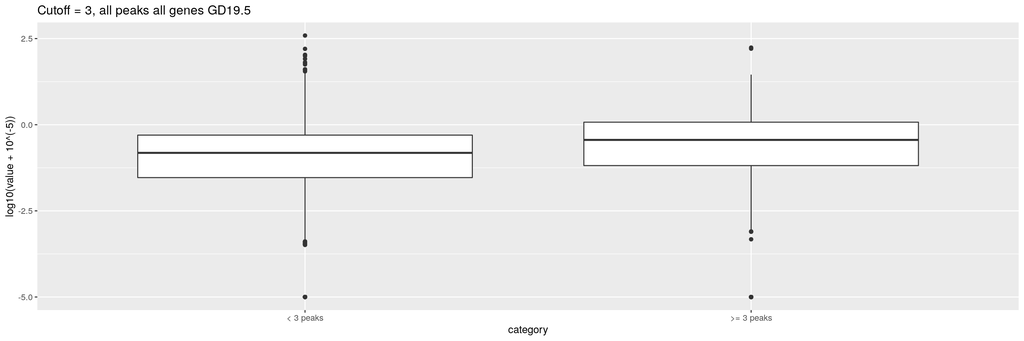

```r
ggplot(df, aes(x=category, y=log10(value+10^(-5)))) + geom_boxplot() + ggtitle("Cutoff = 3, all peaks all genes GD19.5")
```

```r
print("Number of genes with >= 3 peaks:")
```

```
#> [1] "Number of genes with >= 3 peaks:"
```

```r
length(genes)
```

```
#> [1] 519
```

```r
print("Number of genes with < 3 peaks:")
```

```
#> [1] "Number of genes with < 3 peaks:"
```

```r
length(unique(df[df$category == "< 3 peaks", "gene"]))
```

```
#> [1] 6876
```

Markers with >= 3 peaks are not higher expressed than markers with < 3 peaks. Maybe because they are already highly expressed.

```r
c <- rownames(rats@meta.data[rats@meta.data$predicted.id == "Invasive trophoblast cells",])
atac2 <- rats@assays$MACSpeaks[,c]
atac3 <- atac2[rowMeans(atac2) > 0,]
atac3 <- atac2[rowSums(atac2 > 0) >= ncol(atac2)/10, ]
dim(atac3)
```

```
#> [1] 9841  684
```

```r
closest_genes <- ClosestFeature(rats, regions = rownames(atac3))

t <- table(closest_genes$gene_name)

genes <- names(t[t >= 3])

exp <- exp[order(rownames(exp)),]
exp$gene <- rownames(exp)
df <- exp[exp$gene %in% names(t), c("gene", "6")]
colnames(df) <- c("gene", "value")
df2 <- data.frame(gene = setdiff(names(t), df$gene), value = rep(0, length(setdiff(names(t), df$gene))))
names(df2) <- colnames(df)
df <- rbind(df, df2)

df$category <- ifelse(df$gene %in% genes, ">= 3 peaks", "< 3 peaks")

marker <- read.table("/work/LAS/geetu-lab/hhvu/project3_scATAC/scATAC-seq-analysis/4_RNAintegration/scRNA-seqFiles/gd19.5-wilcoxin-cluster6.txt", header = T)

df <- df[df$gene %in% marker$gene,]

wilcox.test(df[df$category == ">= 3 peaks", "value"], df[df$category == "< 3 peaks", "value"])
```

```
#>
#>  Wilcoxon rank sum test with continuity correction
#>
#> data:  df[df$category == ">= 3 peaks", "value"] and df[df$category == "< 3 peaks", "value"]
#> W = 13539, p-value = 0.06652
#> alternative hypothesis: true location shift is not equal to 0
```

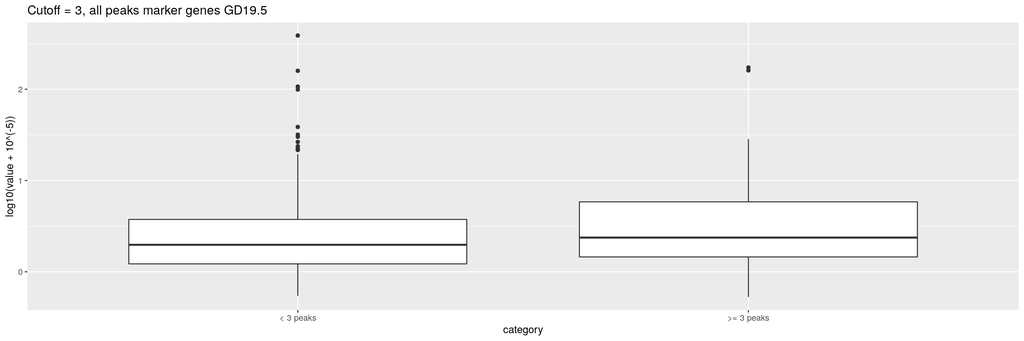

```r
ggplot(df, aes(x=category, y=log10(value+10^(-5)))) + geom_boxplot() + ggtitle("Cutoff = 3, all peaks marker genes GD19.5")
```

Peak distribution of marker genes:

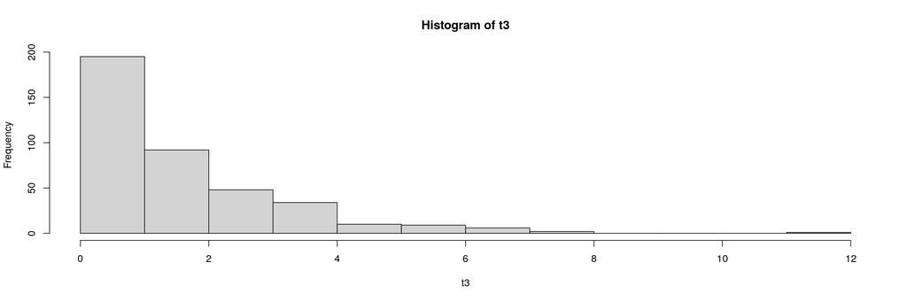

```r
marker <- read.table("/work/LAS/geetu-lab/hhvu/project3_scATAC/scATAC-seq-analysis/4_RNAintegration/scRNA-seqFiles/gd19.5-wilcoxin-cluster6.txt", header = T)
t2 <- t[intersect(names(t),marker$gene)]
non <- setdiff(marker$gene, names(t))
nont <- rep(0, length(non))
names(nont) <- non
t3 <- as.vector(t2)
names(t3) <- names(t2)
t3 <- c(t3, nont)
hist(t3, breaks = seq(0, 12, 1))
```

```r
length(t3[t3 >= 3])
```

```
#> [1] 110
```

Of the markers with peaks, how many peaks are specific

```r
specificPeaks <- read.table("/work/LAS/geetu-lab/hhvu/project3_scATAC/scATAC-seq-analysis/4_RNAintegration/2_MACS2Peaks/annotation_scRNAseq/gd19.5-tbc-toGenes.txt", sep = "\t")
df2 <- closest_genes[closest_genes$gene_name %in% marker$gene,]

#number of specific peaks
length(specificPeaks$query_region)
```

```
#> [1] 2033
```

```r
#number of specific peaks associated to markers
length(intersect(df2$query_region, specificPeaks$query_region))
```

```
#> [1] 339
```

```r
#number of peaks associated to markers
length(df2$query_region)
```

```
#> [1] 765
```

```r
#number of non-specific peaks
length(setdiff(closest_genes$query_region, specificPeaks$query_region))
```

```
#> [1] 7808
```

```r
dat <- data.frame(marker=c(339,765-339), nonmarker=c(2033-339,7808-(2033-339)))
rownames(dat) <- c("specific", "nonspecific")
dat
```

```
#>             marker nonmarker
#> specific       339      1694
#> nonspecific    426      6114
```

```r
fisher.test(dat, alternative = "greater")
```

```
#>
#>  Fisher's Exact Test for Count Data
#>
#> data:  dat
#> p-value < 2.2e-16
#> alternative hypothesis: true odds ratio is greater than 1
#> 95 percent confidence interval:
#>  2.518712      Inf
#> sample estimates:
#> odds ratio
#>   2.871679
```

Markers that only have nonspecific peaks:

```r
nonSpe <- df2[df2$query_region %in% setdiff(closest_genes$query_region, specificPeaks$query_region),]
onlyNonSpe <- nonSpe[!(nonSpe$gene_name %in% specificPeaks$gene_name),]

go_onlyNonSpe <- go(rnor6[rnor6$gene_name %in% onlyNonSpe$gene_name, 1])

go_onlyNonSpe[grep("epith|placenta|actin|vascul", go_onlyNonSpe$Description),]
```

```
#>  [1] ID          Description GeneRatio   BgRatio     pvalue      p.adjust
#>  [7] qvalue      geneID      Count       Fold
#> <0 rows> (or 0-length row.names)
```

```r
go_onlyNonSpe$Description
```

```
#> [1] "substrate adhesion-dependent cell spreading"
#> [2] "protein K48-linked ubiquitination"
#> [3] "cell-substrate adhesion"
#> [4] "intrinsic apoptotic signaling pathway"
```

Markers that only have specific peaks:

```r
onlySpe <- specificPeaks[!(specificPeaks$gene_name %in% nonSpe$gene_name),]
go_onlySpe <- go(rnor6[rnor6$gene_name %in% onlySpe$gene_name, 1])

go_onlySpe[grep("epith|placenta|actin|vascul", go_onlySpe$Description),]
```

```
#>                    ID                                          Description
#> GO:0072073 GO:0072073                        kidney epithelium development
#> GO:0050679 GO:0050679 positive regulation of epithelial cell proliferation
#> GO:0001890 GO:0001890                                 placenta development
#> GO:0030856 GO:0030856        regulation of epithelial cell differentiation
#> GO:0014829 GO:0014829                   vascular smooth muscle contraction
#>              GeneRatio     BgRatio       pvalue    p.adjust      qvalue
#> GO:0072073 0.021663778 0.009105144 4.448727e-05 0.007576316 0.006490742
#> GO:0050679 0.025996534 0.012062866 5.600568e-05 0.008849479 0.007581479
#> GO:0001890 0.021663778 0.010613002 5.220193e-04 0.026194185 0.022440944
#> GO:0030856 0.018197574 0.008757177 1.120047e-03 0.039527245 0.033863573
#> GO:0014829 0.006065858 0.001507858 1.257126e-03 0.042818473 0.036683217
#>                                                                                                                                                                                geneID
#> GO:0072073                                 Aqp11/Irx2/Irx1/Sox9/Adipoq/Robo2/Efnb2/Fgfr1/Gata3/Foxc1/Fgf1/Smad2/Irx3/Notch2/Cd24/Pax8/Bmp2/Jag1/Shh/Ptpro/Osr1/Myc/Smad3/Epha4/Maged1
#> GO:0050679 Tcf7l2/Pold4/C5ar1/Itgb3/Sox9/Rptor/Tp63/Hmgb1/Fgfr1/Wnt5a/Prl/Fgf1/Cdh13/Notch2/Bmp2/Gata2/Itpr1/Cxcl12/Foxp1/Shh/Foxp2/Prkd1/Osr1/Sox11/Myc/Hmga2/Ccr3/Twist2/Pdcl3/Apln
#> GO:0001890                         Ascl2/Hand1/Stc2/Krt19/Cdx2/Pla2g4a/Stc1/Pcdh12/Mc2r/Gab1/Hsd17b2/Notch2/Rxra/Gata2/Pparg/Met/Slc8a1/Epas1/Hif1a/Krt8/E2f7/Zfat/Plcd1/Eomes/Map2k1
#> GO:0030856                                                       Rfx3/Sox9/Krt36/Adipoq/Tp63/Macroh2a1/Msx2/Gata3/Foxc1/Sox2/Cd24/Pax8/Jag1/Foxp1/Shh/Mycn/Tgfb3/Osr1/Btg1/Cd109/Klf7
#> GO:0014829                                                                                                                              Htr2a/Chrm3/Ednra/Adra2b/Slc8a1/Atp2b1/Map2k1
#>            Count     Fold
#> GO:0072073    25 2.379290
#> GO:0050679    30 2.155088
#> GO:0001890    25 2.041249
#> GO:0030856    21 2.078018
#> GO:0014829     7 4.022830
```

Markers with both:

```r
both <- specificPeaks[specificPeaks$gene_name %in% intersect(specificPeaks$gene_name, nonSpe$gene_name),]
go_both <- go(rnor6[rnor6$gene_name %in% both$gene_name, 1])

go_both[grep("epith|placenta|actin|vascul", go_both$Description),]
```

```
#>                    ID                             Description  GeneRatio
#> GO:0010632 GO:0010632 regulation of epithelial cell migration 0.06034483
#>               BgRatio       pvalue   p.adjust     qvalue
#> GO:0010632 0.01299078 0.0008000238 0.04946538 0.04281617
#>                                              geneID Count     Fold
#> GO:0010632 Jup/Serpine1/Fgfbp1/Plk2/Dab2ip/Src/Klf4     7 4.645205
```